# Trade&Ahead Project Debrief

[figure not shown]

## Problem Statement

### Context

The stock market has consistently proven to be a good place to invest in and save for the future. There are a lot of compelling reasons to invest in stocks. It can help in fighting inflation, create wealth, and also provides some tax benefits. Good steady returns on investments over a long period of time can also grow a lot more than seems possible. Also, thanks to the power of compound interest, the earlier one starts investing, the larger the corpus one can have for retirement. Overall, investing in stocks can help meet life's financial aspirations.

It is important to maintain a diversified portfolio when investing in stocks in order to maximise earnings under any market condition. Having a diversified portfolio tends to yield higher returns and face lower risk by tempering potential losses when the market is down. It is often easy to get lost in a sea of financial metrics to analyze while determining the worth of a stock, and doing the same for a multitude of stocks to identify the right picks for an individual can be a tedious task. By doing a cluster analysis, one can identify stocks that exhibit similar characteristics and ones which exhibit minimum correlation. This will help investors better analyze stocks across different market segments and help protect against risks that could make the portfolio vulnerable to losses.

### Objective

Trade&Ahead is a financial consultancy firm who provide their customers with personalized investment strategies. They have hired you as a Data Scientist and provided you with data comprising stock price and some financial indicators for a few companies listed under the New York Stock Exchange. They have assigned you the tasks of analyzing the data, grouping the stocks based on the attributes provided, and sharing insights about the characteristics of each group.

### Data Dictionary

- Ticker Symbol: An abbreviation used to uniquely identify publicly traded shares of a particular stock on a particular stock market
- Company: Name of the company
- GICS Sector: The specific economic sector assigned to a company by the Global Industry Classification Standard (GICS) that best defines its business operations
- GICS Sub Industry: The specific sub-industry group assigned to a company by the Global Industry Classification Standard (GICS) that best defines its business operations
- Current Price: Current stock price in dollars
- Price Change: Percentage change in the stock price in 13 weeks
- Volatility: Standard deviation of the stock price over the past 13 weeks
- ROE: A measure of financial performance calculated by dividing net income by shareholders' equity (shareholders' equity is equal to a company's assets minus its debt)
- Cash Ratio: The ratio of a company's total reserves of cash and cash equivalents to its total current liabilities
- Net Cash Flow: The difference between a company's cash inflows and outflows (in dollars)
- Net Income: Revenues minus expenses, interest, and taxes (in dollars)
- Earnings Per Share: Company's net profit divided by the number of common shares it has outstanding (in dollars)
- Estimated Shares Outstanding: Company's stock currently held by all its shareholders
- P/E Ratio: Ratio of the company's current stock price to the earnings per share
- P/B Ratio: Ratio of the company's stock price per share by its book value per share (book value of a company is the net difference between that company's total assets and total liabilities)

## Importing necessary libraries and data

```python
import warnings
warnings.filterwarnings('ignore')

# Libraries to help with reading and manipulating data
import numpy as np
import pandas as pd

# Libraries to help with data visualization
import matplotlib.pyplot as plt
import seaborn as sns
import plotly.express as px
# Removes the limit for the number of displayed columns
pd.set_option("display.max_columns", None)
# Sets the limit for the number of displayed rows
pd.set_option("display.max_rows", 200)

# to scale the data using z-score
from sklearn.preprocessing import StandardScaler

# to perform k-means clustering
from sklearn.cluster import KMeans

# to perform silhouette analysis
from sklearn.metrics import silhouette_score

# to perform t-SNE
from sklearn.manifold import TSNE

# to compute distances
from scipy.spatial.distance import pdist

# to perform hierarchical clustering, compute cophenetic correlation, and create dendrograms
from sklearn.cluster import AgglomerativeClustering
from scipy.cluster.hierarchy import dendrogram, linkage, cophenet

from scipy.stats import skew
# to perform PCA
from sklearn.decomposition import PCA
```

## Data Overview

- Observations
- Sanity checks

```python
# loading the dataset
data = pd.read_csv("stock_data.csv")
```

```python
data.head()
```

|  | Ticker Symbol | Security | GICS Sector | GICS Sub Industry | Current Price | Price Change | Volatility | ROE | Cash Ratio | Net Cash Flow | Net Income | Earnings Per Share | Estimated Shares Outstanding | P/E Ratio | P/B Ratio |
| --- | --- | --- | --- | --- | --- | --- | --- | --- | --- | --- | --- | --- | --- | --- | --- |
| 0 | AAL | American Airlines Group | Industrials | Airlines | 42.349998 | 9.999995 | 1.687151 | 135 | 51 | -604000000 | 7610000000 | 11.39 | 6.681299e+08 | 3.718174 | -8.784219 |
| 1 | ABBV | AbbVie | Health Care | Pharmaceuticals | 59.240002 | 8.339433 | 2.197887 | 130 | 77 | 51000000 | 5144000000 | 3.15 | 1.633016e+09 | 18.806350 | -8.750068 |
| 2 | ABT | Abbott Laboratories | Health Care | Health Care Equipment | 44.910000 | 11.301121 | 1.273646 | 21 | 67 | 938000000 | 4423000000 | 2.94 | 1.504422e+09 | 15.275510 | -0.394171 |
| 3 | ADBE | Adobe Systems Inc | Information Technology | Application Software | 93.940002 | 13.977195 | 1.357679 | 9 | 180 | -240840000 | 629551000 | 1.26 | 4.996437e+08 | 74.555557 | 4.199651 |
| 4 | ADI | Analog Devices, Inc. | Information Technology | Semiconductors | 55.320000 | -1.827858 | 1.701169 | 14 | 272 | 315120000 | 696878000 | 0.31 | 2.247994e+09 | 178.451613 | 1.059810 |

```python
data.shape
```

```
(340, 15)
```

The dataset has 340 rows and 15 columns

```python
# viewing a random sample of the dataset
data.sample(n=10, random_state=1)
```

|  | Ticker Symbol | Security | GICS Sector | GICS Sub Industry | Current Price | Price Change | Volatility | ROE | Cash Ratio | Net Cash Flow | Net Income | Earnings Per Share | Estimated Shares Outstanding | P/E Ratio | P/B Ratio |
| --- | --- | --- | --- | --- | --- | --- | --- | --- | --- | --- | --- | --- | --- | --- | --- |
| 102 | DVN | Devon Energy Corp. | Energy | Oil & Gas Exploration & Production | 32.000000 | -15.478079 | 2.923698 | 205 | 70 | 830000000 | -14454000000 | -35.55 | 4.065823e+08 | 93.089287 | 1.785616 |
| 125 | FB | Facebook | Information Technology | Internet Software & Services | 104.660004 | 16.224320 | 1.320606 | 8 | 958 | 592000000 | 3669000000 | 1.31 | 2.800763e+09 | 79.893133 | 5.884467 |
| 11 | AIV | Apartment Investment & Mgmt | Real Estate | REITs | 40.029999 | 7.578608 | 1.163334 | 15 | 47 | 21818000 | 248710000 | 1.52 | 1.636250e+08 | 26.335526 | -1.269332 |
| 248 | PG | Procter & Gamble | Consumer Staples | Personal Products | 79.410004 | 10.660538 | 0.806056 | 17 | 129 | 160383000 | 636056000 | 3.28 | 4.913916e+08 | 24.070121 | -2.256747 |
| 238 | OXY | Occidental Petroleum | Energy | Oil & Gas Exploration & Production | 67.610001 | 0.865287 | 1.589520 | 32 | 64 | -588000000 | -7829000000 | -10.23 | 7.652981e+08 | 93.089287 | 3.345102 |
| 336 | YUM | Yum! Brands Inc | Consumer Discretionary | Restaurants | 52.516175 | -8.698917 | 1.478877 | 142 | 27 | 159000000 | 1293000000 | 2.97 | 4.353535e+08 | 17.682214 | -3.838260 |
| 112 | EQT | EQT Corporation | Energy | Oil & Gas Exploration & Production | 52.130001 | -21.253771 | 2.364883 | 2 | 201 | 523803000 | 85171000 | 0.56 | 1.520911e+08 | 93.089287 | 9.567952 |
| 147 | HAL | Halliburton Co. | Energy | Oil & Gas Equipment & Services | 34.040001 | -5.101751 | 1.966062 | 4 | 189 | 7786000000 | -671000000 | -0.79 | 8.493671e+08 | 93.089287 | 17.345857 |
| 89 | DFS | Discover Financial Services | Financials | Consumer Finance | 53.619999 | 3.653584 | 1.159897 | 20 | 99 | 2288000000 | 2297000000 | 5.14 | 4.468872e+08 | 10.431906 | -0.375934 |
| 173 | IVZ | Invesco Ltd. | Financials | Asset Management & Custody Banks | 33.480000 | 7.067477 | 1.580839 | 12 | 67 | 412000000 | 968100000 | 2.26 | 4.283628e+08 | 14.814159 | 4.218620 |

```python
# copying the data to another variable to avoid any changes to original data
df1 = data.copy()
```

```python
# checking datatypes and number of non-null values for each column
df1.info();
```

```
<class 'pandas.core.frame.DataFrame'>
RangeIndex: 340 entries, 0 to 339
Data columns (total 15 columns):
 #   Column                        Non-Null Count  Dtype
---  ------                        --------------  -----
 0   Ticker Symbol                 340 non-null    object
 1   Security                      340 non-null    object
 2   GICS Sector                   340 non-null    object
 3   GICS Sub Industry             340 non-null    object
 4   Current Price                 340 non-null    float64
 5   Price Change                  340 non-null    float64
 6   Volatility                    340 non-null    float64
 7   ROE                           340 non-null    int64
 8   Cash Ratio                    340 non-null    int64
 9   Net Cash Flow                 340 non-null    int64
 10  Net Income                    340 non-null    int64
 11  Earnings Per Share            340 non-null    float64
 12  Estimated Shares Outstanding  340 non-null    float64
 13  P/E Ratio                     340 non-null    float64
 14  P/B Ratio                     340 non-null    float64
dtypes: float64(7), int64(4), object(4)
memory usage: 40.0+ KB
```

**Observations**

- Except for Ticker Symbol,Security,GICS Sector,GICS Sub Industry remaining all the variables are numeric variables.
- We can observe that there are no missing values present.

```python
# Let's look at the statistical summary of the data
df1.describe(include="all").T### Summary of the dataset.
```

|  | count | unique | top | freq | mean | std | min | 25% | 50% | 75% | max |
| --- | --- | --- | --- | --- | --- | --- | --- | --- | --- | --- | --- |
| Ticker Symbol | 340 | 340 | ZTS | 1 | NaN | NaN | NaN | NaN | NaN | NaN | NaN |
| Security | 340 | 340 | Zoetis | 1 | NaN | NaN | NaN | NaN | NaN | NaN | NaN |
| GICS Sector | 340 | 11 | Industrials | 53 | NaN | NaN | NaN | NaN | NaN | NaN | NaN |
| GICS Sub Industry | 340 | 104 | Oil & Gas Exploration & Production | 16 | NaN | NaN | NaN | NaN | NaN | NaN | NaN |
| Current Price | 340.0 | NaN | NaN | NaN | 80.862345 | 98.055086 | 4.5 | 38.555 | 59.705 | 92.880001 | 1274.949951 |
| Price Change | 340.0 | NaN | NaN | NaN | 4.078194 | 12.006338 | -47.129693 | -0.939484 | 4.819505 | 10.695493 | 55.051683 |
| Volatility | 340.0 | NaN | NaN | NaN | 1.525976 | 0.591798 | 0.733163 | 1.134878 | 1.385593 | 1.695549 | 4.580042 |
| ROE | 340.0 | NaN | NaN | NaN | 39.597059 | 96.547538 | 1.0 | 9.75 | 15.0 | 27.0 | 917.0 |
| Cash Ratio | 340.0 | NaN | NaN | NaN | 70.023529 | 90.421331 | 0.0 | 18.0 | 47.0 | 99.0 | 958.0 |
| Net Cash Flow | 340.0 | NaN | NaN | NaN | 55537620.588235 | 1946365312.175789 | -11208000000.0 | -193906500.0 | 2098000.0 | 169810750.0 | 20764000000.0 |
| Net Income | 340.0 | NaN | NaN | NaN | 1494384602.941176 | 3940150279.327936 | -23528000000.0 | 352301250.0 | 707336000.0 | 1899000000.0 | 24442000000.0 |
| Earnings Per Share | 340.0 | NaN | NaN | NaN | 2.776662 | 6.587779 | -61.2 | 1.5575 | 2.895 | 4.62 | 50.09 |
| Estimated Shares Outstanding | 340.0 | NaN | NaN | NaN | 577028337.75403 | 845849595.417695 | 27672156.86 | 158848216.1 | 309675137.8 | 573117457.325 | 6159292035.0 |
| P/E Ratio | 340.0 | NaN | NaN | NaN | 32.612563 | 44.348731 | 2.935451 | 15.044653 | 20.819876 | 31.764755 | 528.039074 |
| P/B Ratio | 340.0 | NaN | NaN | NaN | -1.718249 | 13.966912 | -76.119077 | -4.352056 | -1.06717 | 3.917066 | 129.064585 |

**Observations**

- There are data for 340 stocks with all details of their performance in stock market.
- There are several variables which indicate the how a stock is varying in last 13 weeks.
- Except for name and category of a stock {Ticker Symbol,Security,GICS Sector & GICS Sub-Industry}, all columns are numeric in nature.
- The numerical variables have different ranges and have to be scaled before clustering.
- There are 11 GICS sectors among the data with 340 stock related details.
- There are 104 unique sub industries.
- There are no missing values in the data.

## Exploratory Data Analysis (EDA)

- EDA is an important part of any project involving data.
- It is important to investigate and understand the data better before building a model with it.
- A few questions have been mentioned below which will help you approach the analysis in the right manner and generate insights from the data.
- A thorough analysis of the data, in addition to the questions mentioned below, should be done.

**Questions**:

1. What does the distribution of stock prices look like?
2. The stocks of which economic sector have seen the maximum price increase on average?
3. How are the different variables correlated with each other?
4. Cash ratio provides a measure of a company's ability to cover its short-term obligations using only cash and cash equivalents. How does the average cash ratio vary across economic sectors?
5. P/E ratios can help determine the relative value of a company's shares as they signify the amount of money an investor is willing to invest in a single share of a company per dollar of its earnings. How does the P/E ratio vary, on average, across economic sectors?

```python
# function to create labeled barplots


def labeled_barplot(data, feature, perc=False, n=None):
    """
    Barplot with percentage at the top

    data: dataframe
    feature: dataframe column
    perc: whether to display percentages instead of count (default is False)
    n: displays the top n category levels (default is None, i.e., display all levels)
    """

    total = len(data[feature])  # length of the column
    count = data[feature].nunique()
    if n is None:
        plt.figure(figsize=(count + 1, 5))
    else:
        plt.figure(figsize=(n + 1, 5))

    plt.xticks(rotation=90, fontsize=15)
    ax = sns.countplot(
        data=data,
        x=feature,
        palette="Paired",
        order=data[feature].value_counts().index[:n].sort_values(),
    )

    for p in ax.patches:
        if perc == True:
            label = "{:.1f}%".format(
                100 * p.get_height() / total
            )  # percentage of each class of the category
        else:
            label = p.get_height()  # count of each level of the category

        x = p.get_x() + p.get_width() / 2  # width of the plot
        y = p.get_height()  # height of the plot

        ax.annotate(
            label,
            (x, y),
            ha="center",
            va="center",
            size=12,
            xytext=(0, 5),
            textcoords="offset points",
        )  # annotate the percentage

    plt.show()  # show the plot
```

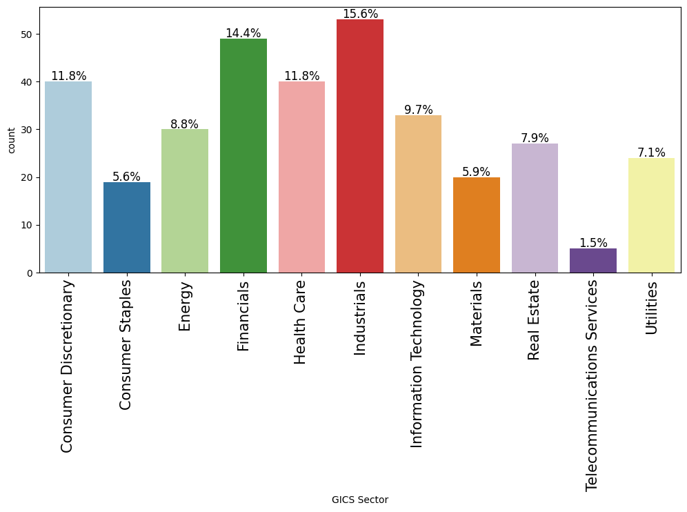

```python
labeled_barplot(df1, "GICS Sector", perc=True) #data of various sectors
```

[figure not shown]

```python
labeled_barplot(df1, "GICS Sub Industry", perc=True)
```

```python
# function to plot a boxplot and a histogram along the same scale.


def histogram_boxplot(data, feature, figsize=(12, 7), kde=False, bins=None):
    """
    Boxplot and histogram combined

    data: dataframe
    feature: dataframe column
    figsize: size of figure (default (12,7))
    kde: whether to the show density curve (default False)
    bins: number of bins for histogram (default None)
    """
    f2, (ax_box2, ax_hist2) = plt.subplots(
        nrows=2,  # Number of rows of the subplot grid= 2
        sharex=True,  # x-axis will be shared among all subplots
        gridspec_kw={"height_ratios": (0.25, 0.75)},
        figsize=figsize,
    )  # creating the 2 subplots
    sns.boxplot(
        data=data, x=feature, ax=ax_box2, showmeans=True, color="violet"
    )  # boxplot will be created and a star will indicate the mean value of the column
    sns.histplot(
        data=data, x=feature, kde=kde, ax=ax_hist2, bins=bins, palette="winter"
    ) if bins else sns.histplot(
        data=data, x=feature, kde=kde, ax=ax_hist2
    )  # For histogram
    ax_hist2.axvline(
        data[feature].mean(), color="green", linestyle="--"
    )  # Add mean to the histogram
    ax_hist2.axvline(
        data[feature].median(), color="black", linestyle="-"
    )  # Add median to the histogram
```

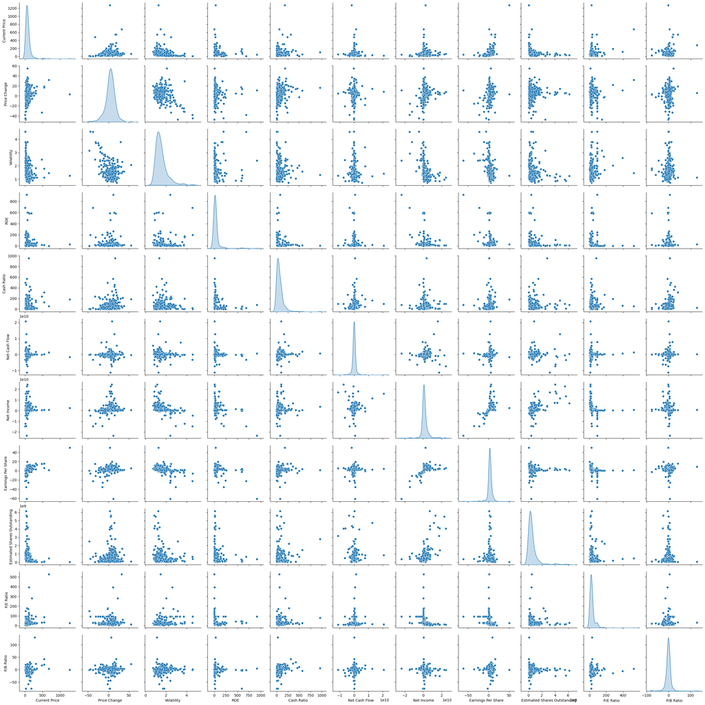

```python
#Visually inspect the covariance between independent dimensions

sns.pairplot(df1, diag_kind='kde')
```

```python
cat_cols = list(df1.select_dtypes('O').columns)
```

```python
num_df = df1.drop(columns=cat_cols)
```

```python
for i in num_df.columns:
  print('The Skewness score for {} is {}'.format(i, skew(num_df[i])))
```

```
The Skewness score for Current Price is 7.0161851998444895
The Skewness score for Price Change is -0.5566869059911508
The Skewness score for Volatility is 2.088159089815732
The Skewness score for ROE is 5.74791931926037
The Skewness score for Cash Ratio is 4.447719675993146
The Skewness score for Net Cash Flow is 3.8307287158003525
The Skewness score for Net Income is 0.9412406727458795
The Skewness score for Earnings Per Share is -2.7095625820357587
The Skewness score for Estimated Shares Outstanding is 3.8283233526122373
The Skewness score for P/E Ratio is 6.679495152226206
The Skewness score for P/B Ratio is 0.8128169484352794
```

- Stock Price,P/E Ratio,ROE, Cash ratio,etc. distribution is rightly skewed having higher number of tail values towards right.
- Earnings Per Share, Price change is left skewed which means mean of these data is typically less than the median due to the influence of lower-valued outliers.
- But Price Change, Net Income, P/B Ratio is almost normal plot

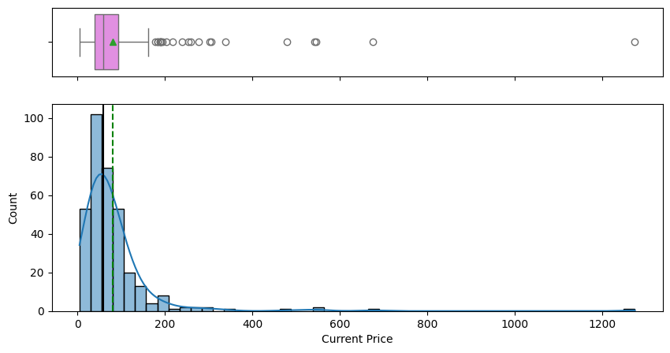

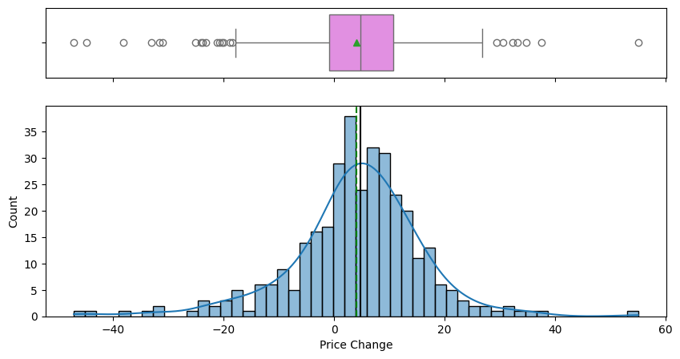

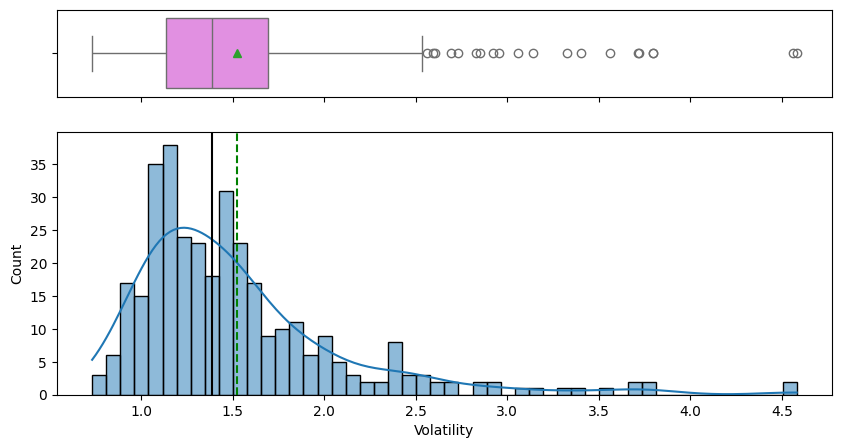

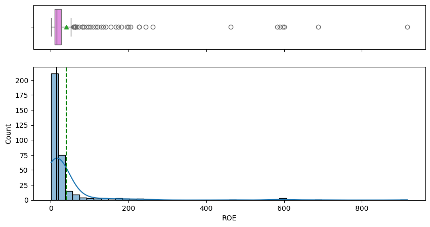

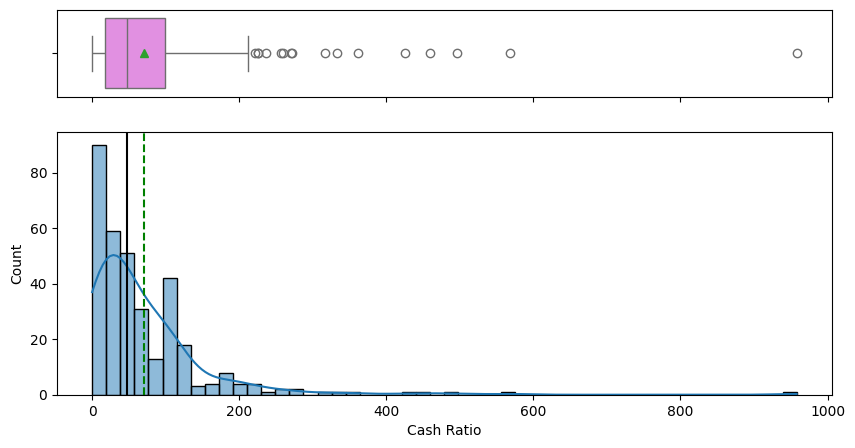

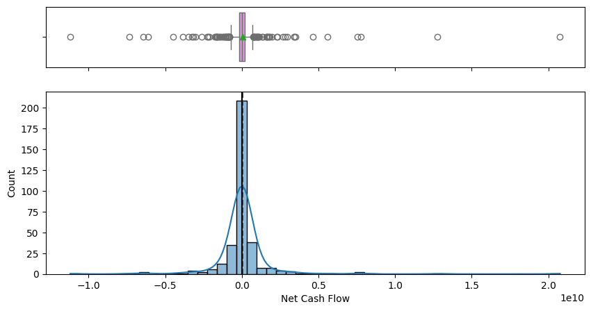

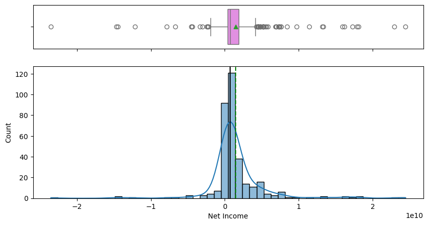

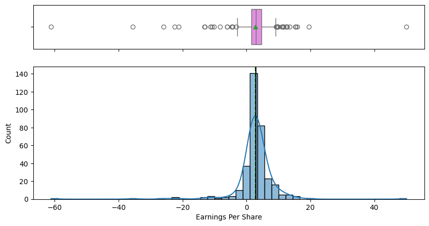

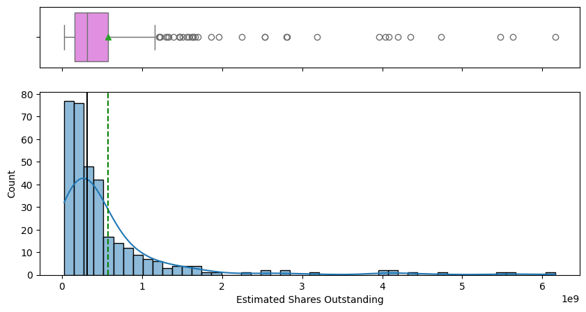

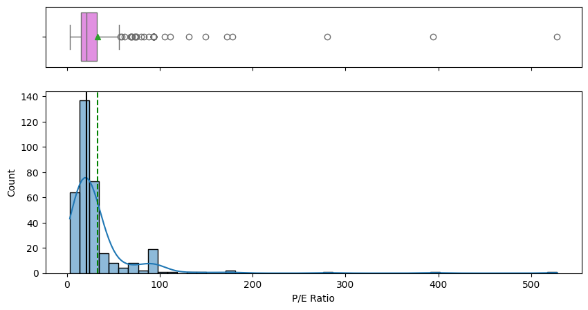

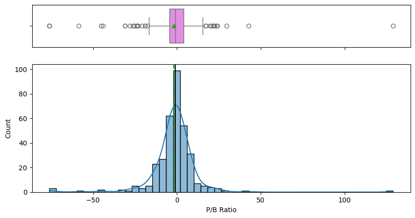

```python
# selecting numerical columns
num_cols = df1.select_dtypes(include=np.number).columns.tolist()

for item in num_cols:
    histogram_boxplot(df1, item, bins=50, kde=True, figsize=(10, 5))
```

- Correlation plot

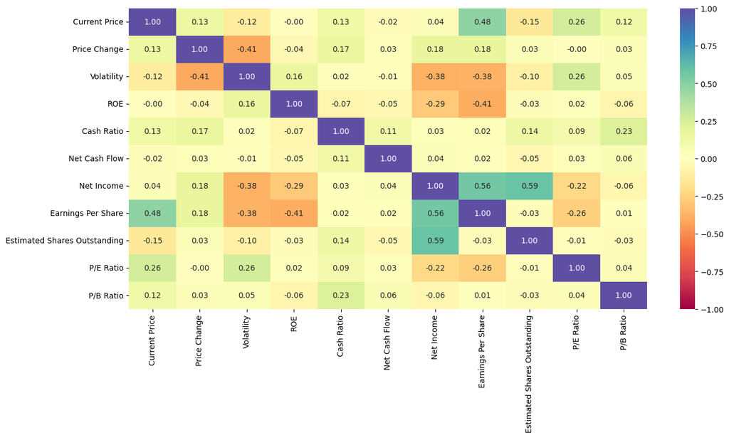

```python
plt.figure(figsize=(15, 7))
sns.heatmap(
    df1[num_cols].corr(), annot=True, vmin=-1, vmax=1, fmt=".2f", cmap="Spectral"
)
plt.show()
```

```
Sector with maximum average price increase: Health Care
Average Price Change: 9.59%
```

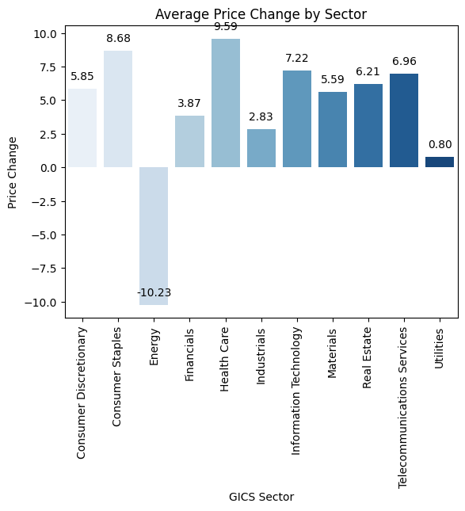

```python
#Group by 'GICS Sector' and calculating mean of 'Price Change'
sector_price_avg = df1.groupby('GICS Sector')['Price Change'].mean().reset_index()

#Identify the sector with the highest average price increase
max_sector = sector_price_avg.loc[sector_price_avg['Price Change'].idxmax()]

#Display the result
print(
    f"Sector with maximum average price increase: {max_sector['GICS Sector']}\n"
    f"Average Price Change: {max_sector['Price Change']:.2f}%"
)
# Create bar plot
ax = sns.barplot(x='GICS Sector', y='Price Change', data=sector_price_avg, palette='Blues')

# Add values above bars
for p in ax.patches:
    ax.text(
        p.get_x() + p.get_width() / 2,  # X-coordinate (center of bar)
        p.get_height() + 0.5,           # Y-coordinate (slightly above bar)
        f'{p.get_height():.2f}',             # Text to display (value of y)
        ha='center', va='bottom',        # Horizontal/vertical alignment
        rotation=0,
        fontsize=10
    )

plt.title('Average Price Change by Sector')
plt.ylabel('Price Change')
plt.xticks(rotation=90)
plt.show()
```

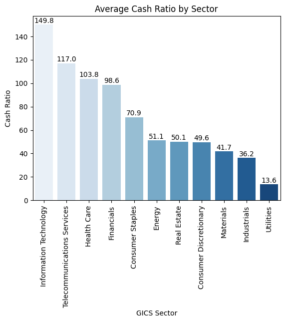

```python
#Group by 'GICS Sector' and calculate average cash ratio
sector_cash_ratio = df1.groupby('GICS Sector')['Cash Ratio'].mean().reset_index()

#Sort results to identify sectors with highest/lowest averages
sector_cash_ratio_sorted = sector_cash_ratio.sort_values(by='Cash Ratio', ascending=False)

# Create bar plot
ax = sns.barplot(x='GICS Sector', y='Cash Ratio', data=sector_cash_ratio_sorted, palette='Blues')

# Add values above bars
for p in ax.patches:
    ax.text(
        p.get_x() + p.get_width() / 2,  # X-coordinate (center of bar)
        p.get_height() + 0.5,           # Y-coordinate (slightly above bar)
        f'{p.get_height():.1f}',             # Text to display (value of y)
        ha='center', va='bottom',        # Horizontal/vertical alignment
        rotation=0,
        fontsize=10
    )

plt.title('Average Cash Ratio by Sector')
plt.ylabel('Cash Ratio')
plt.xticks(rotation=90)
plt.show()
```

- IT has the highest average cash ratio and Utilities GICS sector has the lowest cash ratio

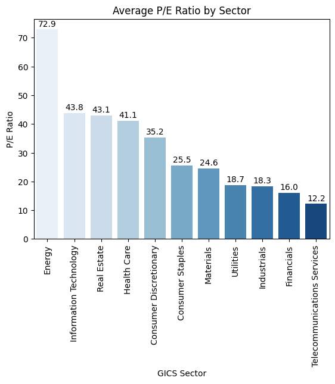

```python
#Group by 'GICS Sector' and calculate average P/E ratio
sector_pe_ratio = df1.groupby('GICS Sector')['P/E Ratio'].mean().reset_index()

#Sort results to identify sectors with highest/lowest averages
sector_pe_ratio_sorted = sector_pe_ratio.sort_values(by='P/E Ratio', ascending=False)

# Create bar plot
ax = sns.barplot(x='GICS Sector', y='P/E Ratio', data=sector_pe_ratio_sorted, palette='Blues')

# Add values above bars
for p in ax.patches:
    ax.text(
        p.get_x() + p.get_width() / 2,  # X-coordinate (center of bar)
        p.get_height() + 0.5,           # Y-coordinate (slightly above bar)
        f'{p.get_height():.1f}',             # Text to display (value of y)
        ha='center', va='bottom',        # Horizontal/vertical alignment
        rotation=0,
        fontsize=10
    )

plt.title('Average P/E Ratio by Sector')
plt.ylabel('P/E Ratio')
plt.xticks(rotation=90)
plt.show()
```

## Data Preprocessing

- Duplicate value check
- Missing value treatment
- Outlier check
- Feature engineering (if needed)
- Any other preprocessing steps (if needed)

```python
# Drop Ticker Symbol since it is a unique identifier
df1.drop(['Ticker Symbol'],axis = 1, inplace = True)
```

```python
df1.isnull().sum()
```

```
Security                        0
GICS Sector                     0
GICS Sub Industry               0
Current Price                   0
Price Change                    0
Volatility                      0
ROE                             0
Cash Ratio                      0
Net Cash Flow                   0
Net Income                      0
Earnings Per Share              0
Estimated Shares Outstanding    0
P/E Ratio                       0
P/B Ratio                       0
dtype: int64
```

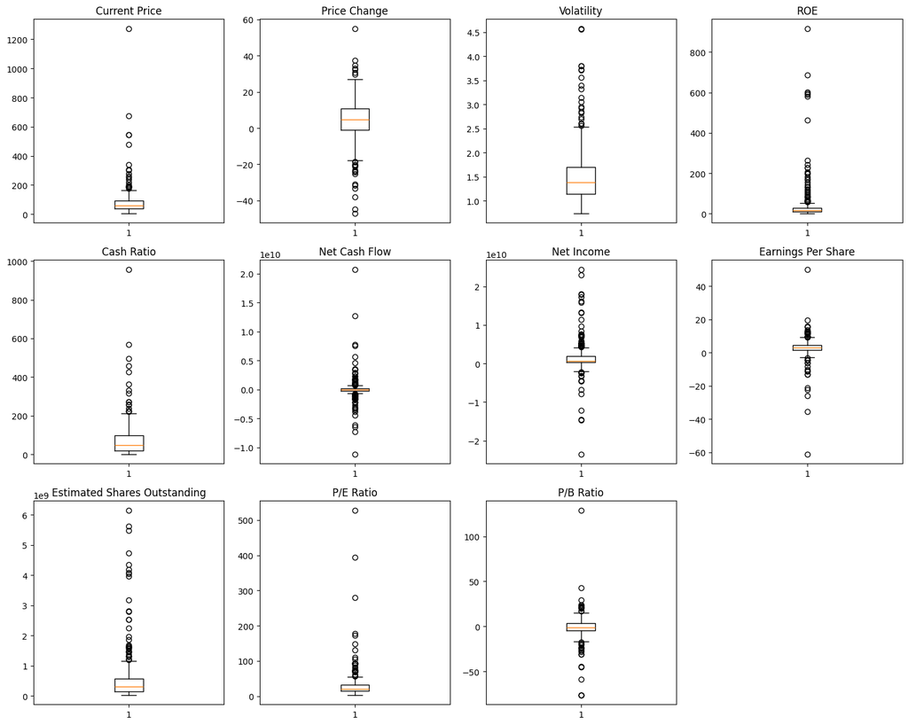

```python
# outlier detection using boxplot
numeric_columns = num_df.columns.tolist()

plt.figure(figsize=(15, 12))

for i, variable in enumerate(numeric_columns):
    plt.subplot(3, 4, i + 1)
    plt.boxplot(df1[variable], whis=1.5)
    plt.tight_layout()
    plt.title(variable)

plt.show()
```

**Observations**

- There are outliers in the columns
- We will not treat the outliers as most of those outliers looks to be OKAY
- These outliers might also form their own cluster.

o We will do feature scaling as all the fields of variety of data to keep them in single scale

```python
#num_df = df1.drop(columns=cat_cols) <- Defined before EDA
sc = StandardScaler()
subset_scaled_df = pd.DataFrame(
    sc.fit_transform(num_df),
    columns=num_df.columns,
)
subset_scaled_df
```

|  | Current Price | Price Change | Volatility | ROE | Cash Ratio | Net Cash Flow | Net Income | Earnings Per Share | Estimated Shares Outstanding | P/E Ratio | P/B Ratio |
| --- | --- | --- | --- | --- | --- | --- | --- | --- | --- | --- | --- |
| 0 | -0.393341 | 0.493950 | 0.272749 | 0.989601 | -0.210698 | -0.339355 | 1.554415 | 1.309399 | 0.107863 | -0.652487 | -0.506653 |
| 1 | -0.220837 | 0.355439 | 1.137045 | 0.937737 | 0.077269 | -0.002335 | 0.927628 | 0.056755 | 1.250274 | -0.311769 | -0.504205 |
| 2 | -0.367195 | 0.602479 | -0.427007 | -0.192905 | -0.033488 | 0.454058 | 0.744371 | 0.024831 | 1.098021 | -0.391502 | 0.094941 |
| 3 | 0.133567 | 0.825696 | -0.284802 | -0.317379 | 1.218059 | -0.152497 | -0.219816 | -0.230563 | -0.091622 | 0.947148 | 0.424333 |
| 4 | -0.260874 | -0.492636 | 0.296470 | -0.265515 | 2.237018 | 0.133564 | -0.202703 | -0.374982 | 1.978399 | 3.293307 | 0.199196 |
| ... | ... | ... | ... | ... | ... | ... | ... | ... | ... | ... | ... |
| 335 | -0.486181 | 0.901646 | 0.540121 | -0.255142 | 4.308162 | -0.559673 | -1.487784 | -1.127481 | 0.429111 | -0.082116 | 0.572194 |
| 336 | -0.289510 | -1.065766 | -0.079703 | 1.062211 | -0.476513 | 0.053235 | -0.051186 | 0.029391 | -0.167741 | -0.337154 | -0.152012 |
| 337 | 0.221913 | 0.439539 | -0.206067 | -0.400362 | 0.332009 | 0.164889 | -0.342467 | -0.303532 | -0.460058 | 2.233634 | -1.589390 |
| 338 | -0.547053 | -0.436811 | -0.097813 | -0.369243 | 0.320933 | -0.051022 | -0.301171 | -0.239684 | -0.377852 | -0.222714 | 0.118680 |
| 339 | -0.336453 | 1.051046 | 0.142671 | -0.078803 | -0.055639 | 0.111378 | -0.293666 | -0.318734 | -0.092942 | 0.854902 | 0.246754 |

340 rows × 11 columns

- As expected, all the attributes have a mean of ~0 and a standard deviation of ~1 after scaling.

## EDA

- It is a good idea to explore the data once again after manipulating it.

```python
subset_scaled_df.describe()
```

|  | Current Price | Price Change | Volatility | ROE | Cash Ratio | Net Cash Flow | Net Income | Earnings Per Share | Estimated Shares Outstanding | P/E Ratio | P/B Ratio |
| --- | --- | --- | --- | --- | --- | --- | --- | --- | --- | --- | --- |
| count | 3.400000e+02 | 3.400000e+02 | 3.400000e+02 | 3.400000e+02 | 3.400000e+02 | 3.400000e+02 | 3.400000e+02 | 3.400000e+02 | 3.400000e+02 | 3.400000e+02 | 3.400000e+02 |
| mean | 7.836868e-18 | -2.873518e-17 | -7.967483e-17 | 2.873518e-17 | -8.098097e-17 | 2.612289e-18 | 1.044916e-17 | 5.747037e-17 | -1.044916e-16 | 7.836868e-18 | 2.612289e-17 |
| std | 1.001474e+00 | 1.001474e+00 | 1.001474e+00 | 1.001474e+00 | 1.001474e+00 | 1.001474e+00 | 1.001474e+00 | 1.001474e+00 | 1.001474e+00 | 1.001474e+00 | 1.001474e+00 |
| min | -7.799176e-01 | -4.271357e+00 | -1.341642e+00 | -4.003618e-01 | -7.755552e-01 | -5.795489e+00 | -6.359977e+00 | -9.725729e+00 | -6.504299e-01 | -6.701624e-01 | -5.334786e+00 |
| 25% | -4.321010e-01 | -4.185350e-01 | -6.618376e-01 | -3.095993e-01 | -5.761937e-01 | -1.283478e-01 | -2.902850e-01 | -1.853369e-01 | -4.951193e-01 | -3.967149e-01 | -1.888527e-01 |
| 50% | -2.160880e-01 | 6.183430e-02 | -2.375644e-01 | -2.551418e-01 | -2.550003e-01 | -2.749658e-02 | -2.000453e-01 | 1.798977e-02 | -3.165424e-01 | -2.663000e-01 | 4.668452e-02 |
| 75% | 1.227409e-01 | 5.519628e-01 | 2.869602e-01 | -1.306675e-01 | 3.209329e-01 | 5.879757e-02 | 1.028417e-01 | 2.802242e-01 | -4.630427e-03 | -1.914502e-02 | 4.040708e-01 |
| max | 1.219567e+01 | 4.251806e+00 | 5.168258e+00 | 9.101176e+00 | 9.834905e+00 | 1.065524e+01 | 5.832629e+00 | 7.192572e+00 | 6.609320e+00 | 1.118762e+01 | 9.377562e+00 |

```python
subset_scaled_df.shape
```

```
(340, 11)
```

## K-means Clustering

```python
# Initiating the t-SNE object
# n_components=2 specifies the number of dimensions to reduce the data to
# n_jobs=-2 specifies to use all but one processor core for parallel computation, which speeds up the process
tsne = TSNE(n_components=2, n_jobs=-2, random_state=0)

# Performing dimensionality reduction on the scaled data
# fit_transform() fits the t-SNE model to the data and transforms it into the specified number of dimensions
tsne_reduced_data = tsne.fit_transform(subset_scaled_df)

# Creating a DataFrame from the reduced data
tsne_2d_data = pd.DataFrame(tsne_reduced_data, columns=(["Feature 1","Feature 2"])) # This DataFrame will have two columns corresponding to the two reduced dimensions
```

```python
tsne_2d_data.head()
```

|  | Feature 1 | Feature 2 |
| --- | --- | --- |
| 0 | 19.836332 | 6.722950 |
| 1 | 19.888496 | 8.393101 |
| 2 | 12.272530 | 11.325973 |
| 3 | 14.022326 | -0.561206 |
| 4 | 15.452809 | 0.629998 |

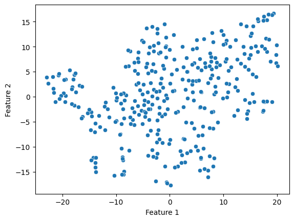

```python
sns.scatterplot(data=tsne_2d_data, x="Feature 1", y="Feature 2");
```

We can roughly see many clusters around atleast 10 will try with different perplexity values and see the plot

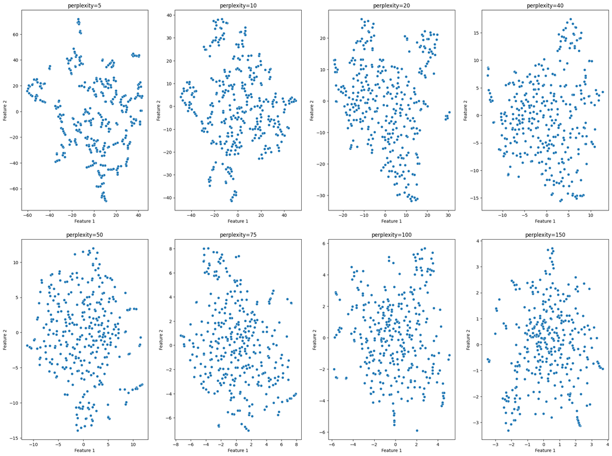

```python
# Define the list of perplexity values to iterate over
perplexities = [5, 10, 20, 40, 50, 75, 100, 150]

plt.figure(figsize=(20, 15))

# Iterate over each perplexity value
for i in range(len(perplexities)):
    # Initiate TSNE with the current perplexity value
    tsne = TSNE(n_components=2, perplexity=perplexities[i], n_jobs=-2, random_state=0)    # n_jobs specifies the nunmber of cores to use for parallel computation; -2 means use all but 1 core
    X_red = tsne.fit_transform(subset_scaled_df)    # fit_transform() fits the TSNE model to the data and transforms it into the specified number of dimensions
    red_data_df = pd.DataFrame(data=X_red, columns=["Feature 1", "Feature 2"])    # creating a new dataframe with reduced dimensions

    # Adjust the subplot grid to 2x4
    plt.subplot(2, 4, i + 1)

    plt.title("perplexity=" + str(perplexities[i]))    # setting plot title
    sns.scatterplot(data=red_data_df, x="Feature 1", y="Feature 2")
    plt.tight_layout(pad=2)

plt.show()
```

- Perplexity 75 seems okay

```python
# Updating 2D TSNE with perplexity 75
# n_components=2 specifies the number of dimensions to reduce the data to
# n_jobs=-2 specifies to use all but one processor core for parallel computation, which speeds up the process
tsne = TSNE(n_components=2, perplexity=75, n_jobs=-2, random_state=0)

# Performing dimensionality reduction on the scaled data
# fit_transform() fits the t-SNE model to the data and transforms it into the specified number of dimensions
tsne_reduced_data = tsne.fit_transform(subset_scaled_df)

# Creating a DataFrame from the reduced data
tsne_2d_data = pd.DataFrame(tsne_reduced_data, columns=(["Feature 1","Feature 2"])) # This DataFrame will have two columns corresponding to the two reduced dimensions
tsne_2d_data.head()
```

|  | Feature 1 | Feature 2 |
| --- | --- | --- |
| 0 | 5.926354 | -1.078761 |
| 1 | 6.108228 | -1.635558 |
| 2 | 4.396082 | -3.453122 |
| 3 | -5.075013 | -0.191209 |
| 4 | -6.037278 | 1.746950 |

```python
#Updating 3D TSNE with perplexity 75
# n_components=3 specifies the number of dimensions to reduce the data to
# n_jobs=-2 specifies to use all but one core for parallel computation, which speeds up the process
tsne = TSNE(n_components=3, perplexity=50, n_jobs=-2, random_state=0)

# Performing dimensionality reduction on the scaled data
# fit_transform() fits the TSNE model to the data and transforms it into the specified number of dimensions
tsne_reduced_data = tsne.fit_transform(subset_scaled_df)

# Creating a DataFrame from the reduced data
tsne_3d_data = pd.DataFrame(tsne_reduced_data, columns=(["Feature 1","Feature 2","Feature 3"])) # This DataFrame will have three columns corresponding to the three reduced dimensions
tsne_3d_data.head()
```

|  | Feature 1 | Feature 2 | Feature 3 |
| --- | --- | --- | --- |
| 0 | -3.071512 | 18.396446 | 37.010788 |
| 1 | 8.106031 | -7.131725 | 28.360523 |
| 2 | -9.909354 | -5.615457 | 30.616854 |
| 3 | -6.420960 | -1.870559 | -38.379017 |
| 4 | -10.805230 | -26.250265 | 22.335810 |

```python
# plotting a 3D scatterplot
fig = px.scatter_3d(tsne_3d_data, x='Feature 1', y='Feature 2', z='Feature 3')
fig.show()
```

[interactive chart not shown]

```python
k_means_df = subset_scaled_df.copy()
```

```python
clusters = range(2, 15)
WCSS = []

for k in clusters:
    model = KMeans(n_clusters=k, random_state=0)
    model.fit(subset_scaled_df)
    prediction = model.predict(k_means_df)

    wcss = model.inertia_


    WCSS.append(wcss)

    print("Number of Clusters:", k, "\twcss:", wcss)
```

```
Number of Clusters: 2 	wcss: 3252.878836775759
Number of Clusters: 3 	wcss: 2956.591419118723
Number of Clusters: 4 	wcss: 2614.030174339841
Number of Clusters: 5 	wcss: 2438.7310567893633
Number of Clusters: 6 	wcss: 2240.0757244270203
Number of Clusters: 7 	wcss: 2157.7482500254087
Number of Clusters: 8 	wcss: 1941.496033723043
Number of Clusters: 9 	wcss: 1774.4665058269547
Number of Clusters: 10 	wcss: 1635.2904277672187
Number of Clusters: 11 	wcss: 1541.3394841641764
Number of Clusters: 12 	wcss: 1410.9270678337386
Number of Clusters: 13 	wcss: 1353.576820221029
Number of Clusters: 14 	wcss: 1280.2316366795515
```

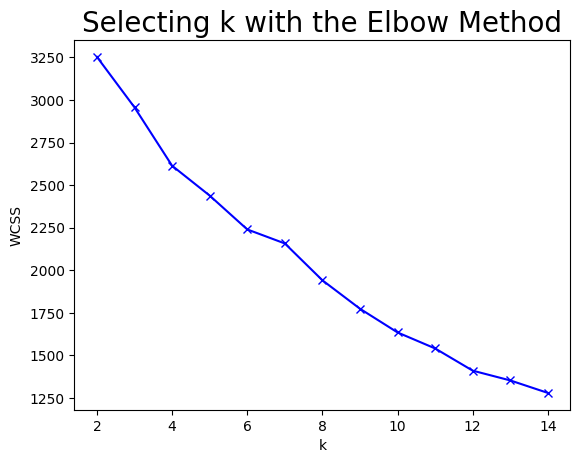

```python
plt.plot(clusters,WCSS,"bx-")
plt.xlabel("k")
plt.ylabel("WCSS")
plt.title("Selecting k with the Elbow Method", fontsize=20)
plt.show()
```

- It is inconclusive to decide from elbow method i will do silhoutte method as well

```python
sil_score = []
cluster_list = range(2, 15)
for n_clusters in cluster_list:
    clusterer = KMeans(n_clusters=n_clusters, random_state=0)
    preds = clusterer.fit_predict((subset_scaled_df))
    score = silhouette_score(k_means_df, preds)
    sil_score.append(score)
    print("For n_clusters = {}, the silhouette score is {})".format(n_clusters, score))
```

```
For n_clusters = 2, the silhouette score is 0.4484662124740991)
For n_clusters = 3, the silhouette score is 0.4357415975612793)
For n_clusters = 4, the silhouette score is 0.45017906939331087)
For n_clusters = 5, the silhouette score is 0.4457476406540732)
For n_clusters = 6, the silhouette score is 0.42032940439396466)
For n_clusters = 7, the silhouette score is 0.4096153564410663)
For n_clusters = 8, the silhouette score is 0.14224550967410426)
For n_clusters = 9, the silhouette score is 0.14473082584974975)
For n_clusters = 10, the silhouette score is 0.15637757068505118)
For n_clusters = 11, the silhouette score is 0.20909518034416136)
For n_clusters = 12, the silhouette score is 0.1641305222591979)
For n_clusters = 13, the silhouette score is 0.16470404313563392)
For n_clusters = 14, the silhouette score is 0.17399384361958023)
```

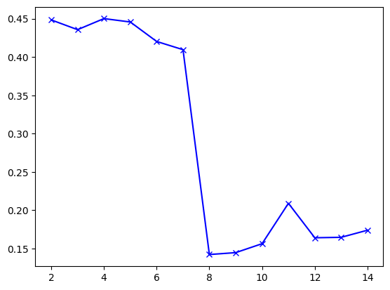

```python
plt.plot(cluster_list, sil_score, "bx-")
plt.show()
```

**Observations**

```python
kmeans = KMeans(n_clusters=5, random_state=0)
kmeans.fit(k_means_df)
```

```
KMeans(n_clusters=5, random_state=0)
```

```python
# Assigning cluster labels to the data frames
k_means_df["K_means_segments"] = kmeans.labels_
subset_scaled_df["K_means_segments"] = kmeans.labels_
num_df["K_means_segments"] = kmeans.labels_
df1["K_means_segments"] = kmeans.labels_
tsne_2d_data["K_means_segments"] = kmeans.labels_
tsne_3d_data["K_means_segments"] = kmeans.labels_
```

```python
tsne_2d_data.head()
```

|  | Feature 1 | Feature 2 | K_means_segments |
| --- | --- | --- | --- |
| 0 | 5.926354 | -1.078761 | 0 |
| 1 | 6.108228 | -1.635558 | 0 |
| 2 | 4.396082 | -3.453122 | 0 |
| 3 | -5.075013 | -0.191209 | 2 |
| 4 | -6.037278 | 1.746950 | 2 |

```python
tsne_3d_data.head()
```

|  | Feature 1 | Feature 2 | Feature 3 | K_means_segments |
| --- | --- | --- | --- | --- |
| 0 | -3.071512 | 18.396446 | 37.010788 | 0 |
| 1 | 8.106031 | -7.131725 | 28.360523 | 0 |
| 2 | -9.909354 | -5.615457 | 30.616854 | 0 |
| 3 | -6.420960 | -1.870559 | -38.379017 | 2 |
| 4 | -10.805230 | -26.250265 | 22.335810 | 2 |

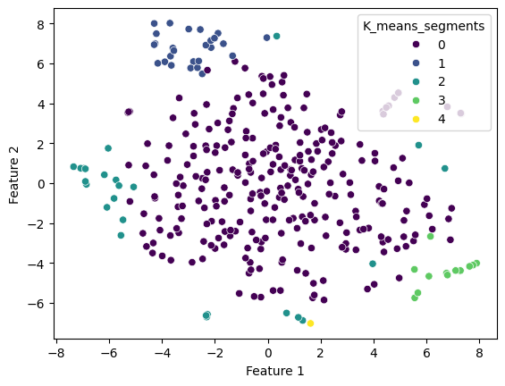

```python
sns.scatterplot(tsne_2d_data, x='Feature 1', y='Feature 2', hue='K_means_segments', palette='viridis');
```

```python
fig = px.scatter_3d(tsne_3d_data, x='Feature 1', y='Feature 2', z='Feature 3', color='K_means_segments')
fig.show()
```

[interactive chart not shown]

```
K_means_segments
0    80.882353
1     7.647059
2     7.352941
3     3.823529
4     0.294118
Name: proportion, dtype: float64
```

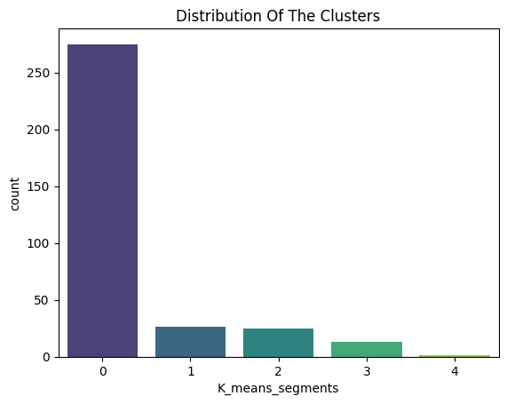

```python
# checking the distribution of the categories in Clusters
print(100*subset_scaled_df['K_means_segments'].value_counts(normalize=True), '\n')

# plotting the count plot for clusters
sns.countplot(data=subset_scaled_df, x='K_means_segments', palette='viridis').set_title("Distribution Of The Clusters");
```

```python
subset_scaled_df
```

|  | Current Price | Price Change | Volatility | ROE | Cash Ratio | Net Cash Flow | Net Income | Earnings Per Share | Estimated Shares Outstanding | P/E Ratio | P/B Ratio | K_means_segments |
| --- | --- | --- | --- | --- | --- | --- | --- | --- | --- | --- | --- | --- |
| 0 | -0.393341 | 0.493950 | 0.272749 | 0.989601 | -0.210698 | -0.339355 | 1.554415 | 1.309399 | 0.107863 | -0.652487 | -0.506653 | 0 |
| 1 | -0.220837 | 0.355439 | 1.137045 | 0.937737 | 0.077269 | -0.002335 | 0.927628 | 0.056755 | 1.250274 | -0.311769 | -0.504205 | 0 |
| 2 | -0.367195 | 0.602479 | -0.427007 | -0.192905 | -0.033488 | 0.454058 | 0.744371 | 0.024831 | 1.098021 | -0.391502 | 0.094941 | 0 |
| 3 | 0.133567 | 0.825696 | -0.284802 | -0.317379 | 1.218059 | -0.152497 | -0.219816 | -0.230563 | -0.091622 | 0.947148 | 0.424333 | 2 |
| 4 | -0.260874 | -0.492636 | 0.296470 | -0.265515 | 2.237018 | 0.133564 | -0.202703 | -0.374982 | 1.978399 | 3.293307 | 0.199196 | 2 |
| ... | ... | ... | ... | ... | ... | ... | ... | ... | ... | ... | ... | ... |
| 335 | -0.486181 | 0.901646 | 0.540121 | -0.255142 | 4.308162 | -0.559673 | -1.487784 | -1.127481 | 0.429111 | -0.082116 | 0.572194 | 2 |
| 336 | -0.289510 | -1.065766 | -0.079703 | 1.062211 | -0.476513 | 0.053235 | -0.051186 | 0.029391 | -0.167741 | -0.337154 | -0.152012 | 0 |
| 337 | 0.221913 | 0.439539 | -0.206067 | -0.400362 | 0.332009 | 0.164889 | -0.342467 | -0.303532 | -0.460058 | 2.233634 | -1.589390 | 0 |
| 338 | -0.547053 | -0.436811 | -0.097813 | -0.369243 | 0.320933 | -0.051022 | -0.301171 | -0.239684 | -0.377852 | -0.222714 | 0.118680 | 0 |
| 339 | -0.336453 | 1.051046 | 0.142671 | -0.078803 | -0.055639 | 0.111378 | -0.293666 | -0.318734 | -0.092942 | 0.854902 | 0.246754 | 0 |

340 rows × 12 columns

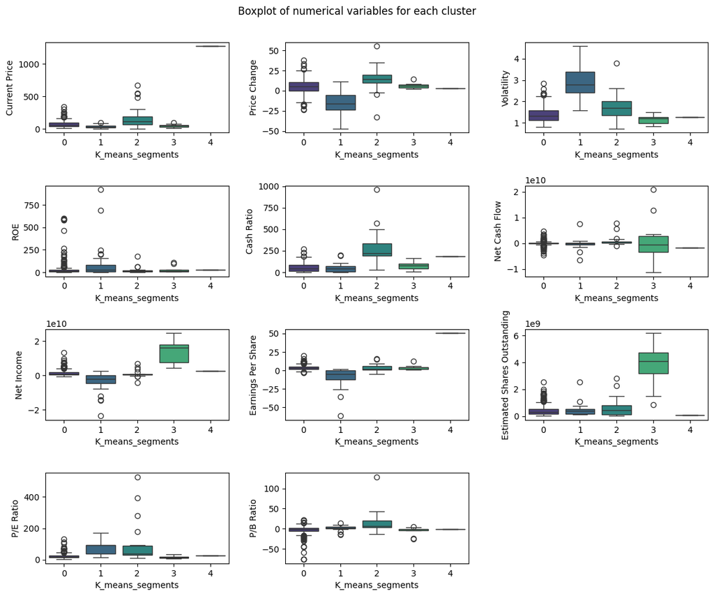

```python
# Prepare for plotting boxplots of numerical variables for each cluster
plt.figure(figsize=(12, 10))  # Set the figure size for the plot
plt.suptitle("Boxplot of numerical variables for each cluster")  # Set the main title for the plot

# Iterate over each numerical variable in the dataframe
for i, variable in enumerate(num_df.columns.to_list()[:-1]):
    plt.subplot(4, 3, i + 1)  # Create subplots in a 3x4 grid, starting from index 1
    sns.boxplot(data=num_df, x='K_means_segments', y=variable, palette='viridis');  # Create a boxplot for current variable and cluster

# Adjust layout of subplots to improve spacing
plt.tight_layout(pad=2.0);
```

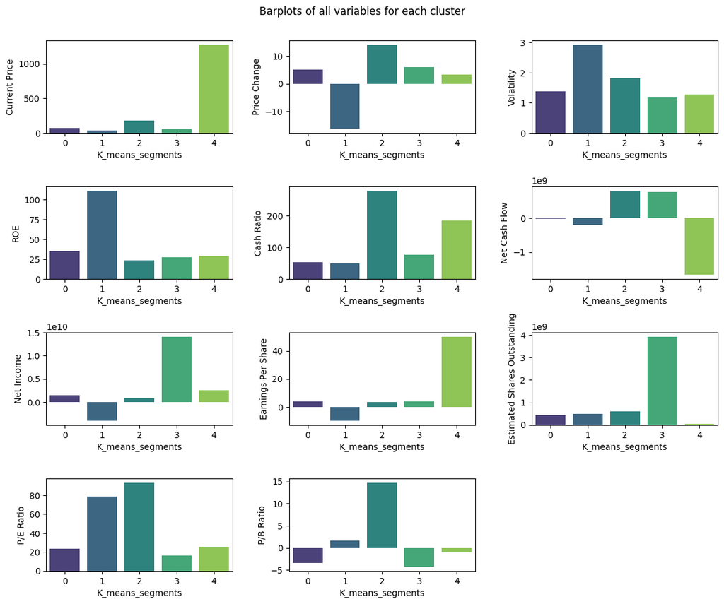

```python
# Prepare for plotting barplots of numerical variables for each cluster
plt.figure(figsize=(12, 10))  # Set the figure size for the plot
plt.suptitle("Barplots of all variables for each cluster")  # Set the main title for the plot

for i, variable in enumerate(num_df.columns.to_list()[:-1]):
    plt.subplot(4, 3, i + 1)
    sns.barplot(data=num_df, x="K_means_segments", y=variable, palette='viridis', errorbar=None)

plt.tight_layout(pad=2.0)
```

```python
# let's see the names of the industries in each cluster
for cl in df1["K_means_segments"].unique():
    print("In cluster {}, the following industries are present:".format(cl))
    print(df1[df1["K_means_segments"] == cl]["GICS Sector"].unique())
    print()
```

```
In cluster 0, the following industries are present:
['Industrials' 'Health Care' 'Consumer Staples' 'Utilities' 'Financials'
 'Real Estate' 'Information Technology' 'Materials'
 'Consumer Discretionary' 'Telecommunications Services' 'Energy']

In cluster 2, the following industries are present:
['Information Technology' 'Health Care' 'Consumer Discretionary'
 'Real Estate' 'Telecommunications Services' 'Energy' 'Consumer Staples'
 'Materials']

In cluster 1, the following industries are present:
['Energy' 'Materials' 'Information Technology' 'Industrials']

In cluster 3, the following industries are present:
['Financials' 'Consumer Discretionary' 'Health Care'
 'Information Technology' 'Consumer Staples' 'Telecommunications Services'
 'Energy']

In cluster 4, the following industries are present:
['Consumer Discretionary']
```

```python
Kmean_cluster_profile = num_df.groupby("K_means_segments").mean()
Kmean_cluster_profile.style.highlight_max(color="lightgreen", axis=0)
```

| K_means_segments | Current Price | Price Change | Volatility | ROE | Cash Ratio | Net Cash Flow | Net Income | Earnings Per Share | Estimated Shares Outstanding | P/E Ratio | P/B Ratio |
| --- | --- | --- | --- | --- | --- | --- | --- | --- | --- | --- | --- |
| 0 | 73.440560 | 5.005125 | 1.386248 | 34.934545 | 52.240000 | -18047505.454545 | 1486648294.545455 | 3.691400 | 428661209.833855 | 23.544684 | -3.407835 |
| 1 | 35.165385 | -16.390175 | 2.922214 | 110.961538 | 49.461538 | -192318884.615385 | -4041692307.692307 | -9.849231 | 482610056.416923 | 78.934814 | 1.612922 |
| 2 | 179.298133 | 14.177395 | 1.809455 | 23.360000 | 278.720000 | 818621280.000000 | 732044960.000000 | 3.338400 | 590618012.638000 | 93.058018 | 14.694419 |
| 3 | 48.103077 | 6.053507 | 1.163964 | 27.538462 | 77.230769 | 773230769.230769 | 14114923076.923077 | 3.958462 | 3918734987.169230 | 16.098039 | -4.253404 |
| 4 | 1274.949951 | 3.190527 | 1.268340 | 29.000000 | 184.000000 | -1671386000.000000 | 2551360000.000000 | 50.090000 | 50935516.070000 | 25.453183 | -1.052429 |

```python
Kmean_cluster_profile.style.highlight_min(color="green", axis=0)
```

| K_means_segments | Current Price | Price Change | Volatility | ROE | Cash Ratio | Net Cash Flow | Net Income | Earnings Per Share | Estimated Shares Outstanding | P/E Ratio | P/B Ratio |
| --- | --- | --- | --- | --- | --- | --- | --- | --- | --- | --- | --- |
| 0 | 73.440560 | 5.005125 | 1.386248 | 34.934545 | 52.240000 | -18047505.454545 | 1486648294.545455 | 3.691400 | 428661209.833855 | 23.544684 | -3.407835 |
| 1 | 35.165385 | -16.390175 | 2.922214 | 110.961538 | 49.461538 | -192318884.615385 | -4041692307.692307 | -9.849231 | 482610056.416923 | 78.934814 | 1.612922 |
| 2 | 179.298133 | 14.177395 | 1.809455 | 23.360000 | 278.720000 | 818621280.000000 | 732044960.000000 | 3.338400 | 590618012.638000 | 93.058018 | 14.694419 |
| 3 | 48.103077 | 6.053507 | 1.163964 | 27.538462 | 77.230769 | 773230769.230769 | 14114923076.923077 | 3.958462 | 3918734987.169230 | 16.098039 | -4.253404 |
| 4 | 1274.949951 | 3.190527 | 1.268340 | 29.000000 | 184.000000 | -1671386000.000000 | 2551360000.000000 | 50.090000 | 50935516.070000 | 25.453183 | -1.052429 |

**Cluster 0:**

**Cluster 1:**

- stocks are from these industries: Energy,Materials,Information Technology,Industrials
- Volatility,Avg ROE is the highest among other clusters
- Price change, Net income, Earnings per share is lowest among other clusters
- Average net income, Earnings per share from the stocks of these clusters are negative (in LOSS)

**Cluster 2:**

**Cluster 3:**

**Cluster 4:**

- stocks are from these industries: Consumer Discretionary
- Net cash flow, P/B Ratio is negative, estimated shares outstanding is lowest
- Current stock Price is is highest

## Hierarchical Clustering

```python
# list of distance metrics
distance_metrics = ["euclidean", "chebyshev", "mahalanobis", "cityblock", "minkowski"]

# list of linkage methods
linkage_methods = ["single", "complete", "average", "weighted"]

high_cophenet_corr = 0
high_dm_lm = [0, 0]

for dm in distance_metrics:
    for lm in linkage_methods:
        Z = linkage(subset_scaled_df, metric=dm, method=lm)
        c, coph_dists = cophenet(Z, pdist(subset_scaled_df))
        print(
            "Cophenetic correlation for {} distance and {} linkage is {}.".format(
                dm.capitalize(), lm, c
            )
        )
        if high_cophenet_corr < c:
            high_cophenet_corr = c
            high_dm_lm[0] = dm
            high_dm_lm[1] = lm
```

```
Cophenetic correlation for Euclidean distance and single linkage is 0.9313241633079515.
Cophenetic correlation for Euclidean distance and complete linkage is 0.8295333659383926.
Cophenetic correlation for Euclidean distance and average linkage is 0.9416238166024387.
Cophenetic correlation for Euclidean distance and weighted linkage is 0.8915125652655655.
Cophenetic correlation for Chebyshev distance and single linkage is 0.9178714159989579.
Cophenetic correlation for Chebyshev distance and complete linkage is 0.7864832447660687.
Cophenetic correlation for Chebyshev distance and average linkage is 0.9348733238681383.
Cophenetic correlation for Chebyshev distance and weighted linkage is 0.9047784117004409.
Cophenetic correlation for Mahalanobis distance and single linkage is 0.9280581106150323.
Cophenetic correlation for Mahalanobis distance and complete linkage is 0.8299455011351382.
Cophenetic correlation for Mahalanobis distance and average linkage is 0.9429480848342714.
Cophenetic correlation for Mahalanobis distance and weighted linkage is 0.8961518916602836.
Cophenetic correlation for Cityblock distance and single linkage is 0.9198517061352128.
Cophenetic correlation for Cityblock distance and complete linkage is 0.7249200473922841.
Cophenetic correlation for Cityblock distance and average linkage is 0.9072001498839215.
Cophenetic correlation for Cityblock distance and weighted linkage is 0.8512512511194313.
Cophenetic correlation for Minkowski distance and single linkage is 0.9313241633079515.
Cophenetic correlation for Minkowski distance and complete linkage is 0.8295333659383926.
Cophenetic correlation for Minkowski distance and average linkage is 0.9416238166024387.
Cophenetic correlation for Minkowski distance and weighted linkage is 0.8915125652655655.
```

```python
# printing the combination of distance metric and linkage method with the highest cophenetic correlation
print(
    "Highest cophenetic correlation is {}, which is obtained with {} distance and {} linkage.".format(
        high_cophenet_corr, high_dm_lm[0].capitalize(), high_dm_lm[1]
    )
)
```

```
Highest cophenetic correlation is 0.9429480848342714, which is obtained with Mahalanobis distance and average linkage.
```

```python
# list of linkage methods with Euclidean metric
linkage_methods = ["single", "complete", "average", "weighted"]

high_cophenet_corr = 0
high_dm_lm = [0, 0]

for lm in linkage_methods:
    Z = linkage(subset_scaled_df, metric="Mahalanobis", method=lm)
    c, coph_dists = cophenet(Z, pdist(subset_scaled_df))
    print("Cophenetic correlation for {} linkage is {}.".format(lm, c))
    if high_cophenet_corr < c:
        high_cophenet_corr = c
        high_dm_lm[0] = "Mahalanobis"
        high_dm_lm[1] = lm
```

```
Cophenetic correlation for single linkage is 0.9280581106150323.
Cophenetic correlation for complete linkage is 0.8299455011351382.
Cophenetic correlation for average linkage is 0.9429480848342714.
Cophenetic correlation for weighted linkage is 0.8961518916602836.
```

```python
# printing the combination of distance metric and linkage method with the highest cophenetic correlation
print(
    "Highest cophenetic correlation is {}, which is obtained with {} linkage.".format(
        high_cophenet_corr, high_dm_lm[1]
    )
)
```

```
Highest cophenetic correlation is 0.9429480848342714, which is obtained with average linkage.
```

**We see that the cophenetic correlation is maximum with Mahalanobis distance and average linkage.**

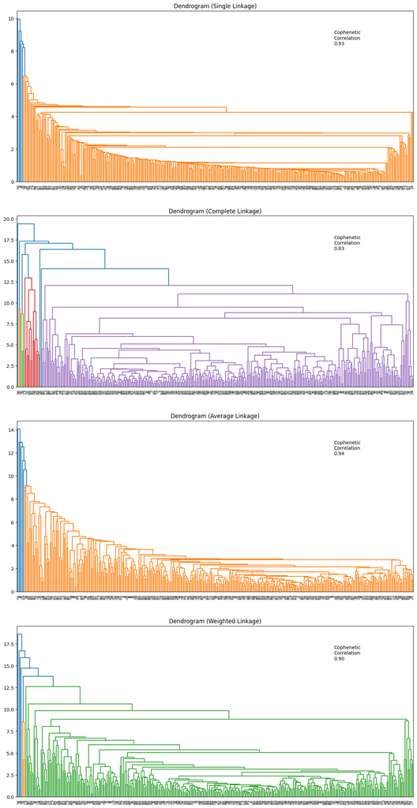

```python
# list of linkage methods
linkage_methods = ["single", "complete", "average", "weighted"]

# lists to save results of cophenetic correlation calculation
compare_cols = ["Linkage", "Cophenetic Coefficient"]

# to create a subplot image
fig, axs = plt.subplots(len(linkage_methods), 1, figsize=(15, 30))

# We will enumerate through the list of linkage methods above
# For each linkage method, we will plot the dendrogram and calculate the cophenetic correlation
for i, method in enumerate(linkage_methods):
    Z = linkage(subset_scaled_df, metric="Mahalanobis", method=method)

    dendrogram(Z, ax=axs[i])
    axs[i].set_title(f"Dendrogram ({method.capitalize()} Linkage)")

    coph_corr, coph_dist = cophenet(Z, pdist(subset_scaled_df))
    axs[i].annotate(
        f"Cophenetic\nCorrelation\n{coph_corr:0.2f}",
        (0.80, 0.80),
        xycoords="axes fraction",
    )
```

**Observations**

- The cophenetic correlation is highest for average linkage methods.
- We will move ahead with average linkage.
- 4 appears to be the appropriate number of clusters from the dendrogram for average linkage.

```python
HCmodel = AgglomerativeClustering(n_clusters=4, metric="mahalanobis", linkage="average")
HCmodel.fit(subset_scaled_df)
```

```
AgglomerativeClustering(linkage='average', metric='mahalanobis', n_clusters=4)
```

```python
subset_scaled_df["HC_Clusters"] = HCmodel.labels_
df1["HC_Clusters"] = HCmodel.labels_
num_df["HC_Clusters"] = HCmodel.labels_
# Assigning cluster labels to the data frames
```

```python
cluster_profile = num_df.groupby("HC_Clusters").mean()
```

```python
# let's see the names of the industries in each cluster
for cl in df1["HC_Clusters"].unique():
    print("In cluster {}, the following industries are present:".format(cl))
    print(df1[df1["HC_Clusters"] == cl]["GICS Sector"].unique())
    print()
```

```
In cluster 0, the following industries are present:
['Industrials' 'Health Care' 'Information Technology' 'Consumer Staples'
 'Utilities' 'Financials' 'Real Estate' 'Materials'
 'Consumer Discretionary' 'Energy' 'Telecommunications Services']

In cluster 3, the following industries are present:
['Consumer Discretionary']

In cluster 2, the following industries are present:
['Energy']

In cluster 1, the following industries are present:
['Consumer Discretionary']
```

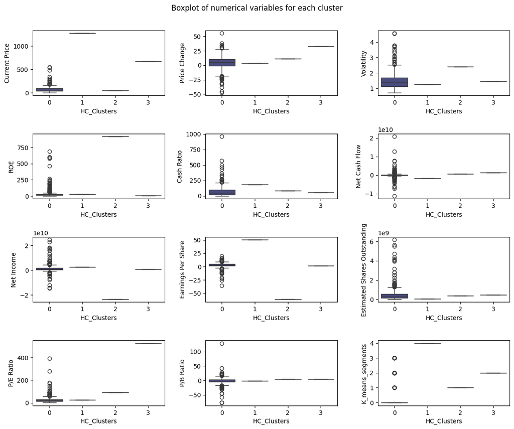

```python
# Prepare for plotting boxplots of numerical variables for each cluster
plt.figure(figsize=(12, 10))  # Set the figure size for the plot
plt.suptitle("Boxplot of numerical variables for each cluster")  # Set the main title for the plot

# Iterate over each numerical variable in the dataframe
for i, variable in enumerate(num_df.columns.to_list()[:-1]):
    plt.subplot(4, 3, i + 1)  # Create subplots in a 3x4 grid, starting from index 1
    sns.boxplot(data=num_df, x='HC_Clusters', y=variable, palette='viridis');  # Create a boxplot for current variable and cluster

# Adjust layout of subplots to improve spacing
plt.tight_layout(pad=2.0);
```

```python
cluster_profile.style.highlight_min(color="green", axis=0)
```

| HC_Clusters | Current Price | Price Change | Volatility | ROE | Cash Ratio | Net Cash Flow | Net Income | Earnings Per Share | Estimated Shares Outstanding | P/E Ratio | P/B Ratio | K_means_segments |
| --- | --- | --- | --- | --- | --- | --- | --- | --- | --- | --- | --- | --- |
| 0 | 75.661387 | 3.975458 | 1.524326 | 37.130564 | 69.691395 | 54964916.913947 | 1568164406.528190 | 2.830549 | 579491483.311276 | 30.984243 | -1.756758 | 0.332344 |
| 1 | 1274.949951 | 3.190527 | 1.268340 | 29.000000 | 184.000000 | -1671386000.000000 | 2551360000.000000 | 50.090000 | 50935516.070000 | 25.453183 | -1.052429 | 4.000000 |
| 2 | 44.470001 | 11.397804 | 2.405408 | 917.000000 | 80.000000 | 698000000.000000 | -23528000000.000000 | -61.200000 | 384444444.400000 | 93.089287 | 4.970809 | 1.000000 |
| 3 | 675.890015 | 32.268105 | 1.460386 | 4.000000 | 58.000000 | 1333000000.000000 | 596000000.000000 | 1.280000 | 465625000.000000 | 528.039074 | 3.904430 | 2.000000 |

```python
# lets display cluster profile
cluster_profile.style.highlight_max(color="lightgreen", axis=0)
```

| HC_Clusters | Current Price | Price Change | Volatility | ROE | Cash Ratio | Net Cash Flow | Net Income | Earnings Per Share | Estimated Shares Outstanding | P/E Ratio | P/B Ratio | K_means_segments |
| --- | --- | --- | --- | --- | --- | --- | --- | --- | --- | --- | --- | --- |
| 0 | 75.661387 | 3.975458 | 1.524326 | 37.130564 | 69.691395 | 54964916.913947 | 1568164406.528190 | 2.830549 | 579491483.311276 | 30.984243 | -1.756758 | 0.332344 |
| 1 | 1274.949951 | 3.190527 | 1.268340 | 29.000000 | 184.000000 | -1671386000.000000 | 2551360000.000000 | 50.090000 | 50935516.070000 | 25.453183 | -1.052429 | 4.000000 |
| 2 | 44.470001 | 11.397804 | 2.405408 | 917.000000 | 80.000000 | 698000000.000000 | -23528000000.000000 | -61.200000 | 384444444.400000 | 93.089287 | 4.970809 | 1.000000 |
| 3 | 675.890015 | 32.268105 | 1.460386 | 4.000000 | 58.000000 | 1333000000.000000 | 596000000.000000 | 1.280000 | 465625000.000000 | 528.039074 | 3.904430 | 2.000000 |

```python
cov_matrix = np.cov(subset_scaled_df.T)
print('Covariance Matrix \n', cov_matrix)
eigenvalues, eigenvectors = np.linalg.eig(cov_matrix)
print('Eigen Vectors \n', eigenvectors)
print('\n Eigen Values \n', eigenvalues)
```

[output not shown]

[output cut: 56 more lines]

[output not shown]

```python
num_df.head()
```

|  | Current Price | Price Change | Volatility | ROE | Cash Ratio | Net Cash Flow | Net Income | Earnings Per Share | Estimated Shares Outstanding | P/E Ratio | P/B Ratio | K_means_segments | HC_Clusters |
| --- | --- | --- | --- | --- | --- | --- | --- | --- | --- | --- | --- | --- | --- |
| 0 | 42.349998 | 9.999995 | 1.687151 | 135 | 51 | -604000000 | 7610000000 | 11.39 | 6.681299e+08 | 3.718174 | -8.784219 | 0 | 0 |
| 1 | 59.240002 | 8.339433 | 2.197887 | 130 | 77 | 51000000 | 5144000000 | 3.15 | 1.633016e+09 | 18.806350 | -8.750068 | 0 | 0 |
| 2 | 44.910000 | 11.301121 | 1.273646 | 21 | 67 | 938000000 | 4423000000 | 2.94 | 1.504422e+09 | 15.275510 | -0.394171 | 0 | 0 |
| 3 | 93.940002 | 13.977195 | 1.357679 | 9 | 180 | -240840000 | 629551000 | 1.26 | 4.996437e+08 | 74.555557 | 4.199651 | 2 | 0 |
| 4 | 55.320000 | -1.827858 | 1.701169 | 14 | 272 | 315120000 | 696878000 | 0.31 | 2.247994e+09 | 178.451613 | 1.059810 | 2 | 0 |

**Insights:-** **Cluster 0:**

- stocks are from these industries: Industrials,Health Care,Information Technology,Consumer Staples,Utilities,Financials,Real Estate,Materials,Consumer Discretionary,Energy,Telecommunications Services
- Avg P/B Ratio of this cluster is lowest

**Cluster 1:**

- stocks are from these industries: Consumer Discretionary
- Avg Volatility , Net Cash flow, Estimated SHares outstanding, P/E Ratio is the lowest
- Current Price, Earnings per share is the highest

**Cluster 2:**

**Cluster 3:**

```python
# Count rows in each HC_Clusters
cluster_counts = df1.groupby('HC_Clusters').size()

# Print the results
print(cluster_counts)
```

```
HC_Clusters
0    337
1      1
2      1
3      1
dtype: int64
```

```python
# Count rows in each HC_Clusters
cluster_counts = df1.groupby('K_means_segments').size()

# Print the results
print(cluster_counts)
```

```
K_means_segments
0    275
1     26
2     25
3     13
4      1
dtype: int64
```

## K-means vs Hierarchical Clustering

0 Which clustering technique took less time for execution?

- Both technique seems to took similar amount of time in execution, but observed is hierarchical took little more time compared to k-means

0 Which clustering technique gave you more distinct clusters, or are they the same?

- It gave similar amount of clusters, and difficult to identify distinct clusters, but the K-means appear to be the most varied approach

0 How many observations are there in the similar clusters of both algorithms?

**K- means segments**

- 0 275
- 1 26
- 2 25
- 3 13
- 4 1

**HC Clusters**

- 0 337
- 1 1
- 2 1
- 3 1

0 How many clusters are obtained as the appropriate number of clusters from both algorithms?

- 5 clusters are obtained in K-means whereas 4 in heirarchical clustering
- in both diverse different clusters are observed where in K-Means more distribution and many industires are mapped to each of the clusters but in HC majority of the clusters are mapped to only 1 and few of them have only single entry which suggests HC is highly dependednt on outliers

## Actionable Insights and Recommendations

- If stock selection is needed, it should be recommended from segment 4 which has highest Earnings per share but it comes with highest current stock price range
- But stock from 4th segment may come with industry which is having more cash outflow than inflow
- Based on K-Means segmentation clusters stock picking can be done and suggestions can be made by the agency
- K-Means segments are considered which is classifying better in comparison to Hierarchical method